# History of dominance hierarchy research - title term use

Liz Hobson (elizabeth.hobson@uc.edu)

# 1 Load packages/functions & data

```r
library(tidyverse)
```

```r
library(igraph)
library(reshape2)
library(RColorBrewer)
library(gridExtra)
#convert dataframe to matri=x==x
matrix.please <- function(x) {
  m<-as.matrix(x[,-1])
  rownames(m)<-x[,1]
  m
}

# Import data and exclude any year prior to 1922
d.stem <- read_csv("Data_stemmed.title.terms.csv") #
```

# 2 PART 1: Clean the stemmed title terms

## 2.1 How many stemmed terms are in each title? (Whole corpus, no minimum use)

```r
d.stem.counttermsXdoc <- d.stem %>% group_by(year, decade, docID) %>% summarize(n.terms = n())
# summarize number of title terms by decade
d.stem.counttermsXdocXdecade <- d.stem.counttermsXdoc %>% group_by(decade) %>% summarize(n.docs=n(),
                                                                                          mean.nterms = mean(n.terms),
                                                                                          median.nterms=median(n.terms),
                                                                                          min.nterms = min(n.terms),
                                                                                          max.nterms = max(n.terms))
```

Title length was relatively consistent across the dataset with on median number of title terms per title ranging from 5 to 9 with an average median number of terms per decade of 6.9090909

## 2.2 Summarize title term use by publication

```r
d.stem.countXdoc <- d.stem %>% group_by(year, decade, docID, stemmed.term) %>% summarize(countXdoc = n())
d.stem.countXdoc
```

| year | decade | docID | stemmed.term | countXdoc |
| --- | --- | --- | --- | --- |
| 1925 | 1920 | 10 | american | 1 |
| 1925 | 1920 | 10 | dr | 1 |
| 1925 | 1920 | 10 | gk | 1 |
| 1925 | 1920 | 10 | histori | 1 |
| 1925 | 1920 | 10 | museum | 1 |
| 1925 | 1920 | 10 | natur | 1 |
| 1925 | 1920 | 10 | nobl | 1 |
| 1928 | 1920 | 11 | evolut | 1 |
| 1928 | 1920 | 11 | fit | 1 |
| 1928 | 1920 | 11 | social | 1 |

[output cut: 9990 more lines]

```r
max(d.stem.countXdoc$countXdoc)
```

```
## [1] 11
```

```r
d.stem.countXdoc$presenceXdoc <- 1

#get rid of any NAs accidentally introduced
d.stem.countXdoc <- d.stem.countXdoc[complete.cases(d.stem.countXdoc),]
unique(is.na(d.stem.countXdoc$stemmed.term))
```

```
## [1] FALSE
```

## 2.3 Summarize title term use by publication & clean

Only counts title term use (terms can be used a maximum of once per title).

```r
term.useXall <- d.stem.countXdoc %>% group_by(stemmed.term) %>% summarize (count.total.term.presence = n())

term.useXnon.rare <- subset(term.useXall, count.total.term.presence>=25)
term.useXnon.rare$term.length <- stringr::str_length(term.useXnon.rare$stemmed.term)

#exclude any term with only one character
cleaned.stemmed <- subset(term.useXnon.rare, term.length>1)
min(cleaned.stemmed$term.length)
```

```
## [1] 2
```

## 2.4 Merge cleaned title terms back to main database with publication information

Use “term.useXnon.rare” to retain only words used in at least 25 documents out the large database. Use merge to retain only rows matching the cleaned title terms.

```r
d.stem.countXdoc.usedterms <- merge(d.stem.countXdoc, cleaned.stemmed, by="stemmed.term", all.y=TRUE)

# number records prior to exclusion
nrow(d.stem.countXdoc)
```

```
## [1] 199672
```

```r
# number records after rarely used words excluded
nrow(d.stem.countXdoc.usedterms)
```

```
## [1] 138452
```

```r
length(unique(d.stem.countXdoc.usedterms$stemmed.term))
```

```
## [1] 1295
```

```r
# number of stemmed terms in full dataset
length(unique(d.stem.countXdoc$stemmed.term))
```

```
## [1] 22406
```

```r
# save data as cached (use this dataframe for term co-occurrence networks)
#write.csv(d.stem.countXdoc.usedterms, "d.stem.countXdoc.usedterms.csv", row.names=FALSE)
```

After excluding rarely used terms found in fewer than 25 separate publications, the database contained 1295 unique terms (of a total of 22406 unique stemmed terms in titles in the full database. This threshold removes very rarely-used terms)

## 2.5 How many stemmed terms are in each title? (MINIMUM USE 25 publications)

```r
d.stem.countXdoc.usedtermsXdoc <- d.stem.countXdoc.usedterms %>% group_by(year, decade, docID) %>% summarize(n.terms = n())
# summarize number of title terms by decade
d.stem.countXdoc.usedtermsXdocXdecade <- d.stem.countXdoc.usedtermsXdoc %>% group_by(decade) %>% summarize(n.docs=n(),
                                                                                          mean.nterms = mean(n.terms),
                                                                                          median.nterms=median(n.terms),
                                                                                          min.nterms = min(n.terms),
                                                                                          max.nterms = max(n.terms))
```

Title length was relatively consistent across the dataset with on median number of title terms per title ranging from 3 to 6 with an average median number of terms per decade of 4.7727273. Maximum number of stemmed title terms used in titles (after filtering to retain only title terms used in at least 25 publications in the entire dataset) did increase over time, with fewer common title terms in earlier decades and more in later decades, although this pattern has plateaued since 1970.

# 3 PART 2 analyses:

## 3.1 Pool by decade to look for changes in word usage

```r
# SUMMARIZE: how many times is each term present in each decade?
summ_terms.presXdecade <- d.stem.countXdoc.usedterms %>%
                              group_by(decade, stemmed.term) %>%
                              summarize(ntimes.termpresentXdec=sum(presenceXdoc))
head(summ_terms.presXdecade,10)
```

| decade | stemmed.term | ntimes.termpresentXdec |
| --- | --- | --- |
| 1920 | american | 1 |
| 1920 | evolut | 1 |
| 1920 | fit | 1 |
| 1920 | histori | 1 |
| 1920 | natur | 1 |
| 1920 | social | 1 |
| 1930 | anim | 1 |
| 1930 | applic | 1 |
| 1930 | behavior | 3 |
| 1930 | concept | 1 |

```r
# make data wide format (terms in rows, decades in columns)
summ_terms.presXdecade.cast <- reshape2::dcast(summ_terms.presXdecade, stemmed.term ~ decade, value.var="ntimes.termpresentXdec")
head(summ_terms.presXdecade.cast,20)
```

|  | stemmed.term | 1920 | 1930 | 1940 | 1950 | 1960 | 1970 | 1980 | 1990 | 2000 | 2010 | 2020 |
| --- | --- | --- | --- | --- | --- | --- | --- | --- | --- | --- | --- | --- |
| 1 | abil | NA | NA | NA | NA | NA | 3 | 7 | 10 | 21 | 29 | 5 |
| 2 | absenc | NA | NA | NA | NA | NA | 2 | 4 | 7 | 5 | 10 | 2 |
| 3 | abund | NA | NA | NA | NA | NA | 1 | 3 | 13 | 17 | 18 | 2 |
| 4 | abus | NA | NA | NA | NA | NA | 2 | 4 | 9 | 15 | 6 | NA |
| 5 | access | NA | NA | NA | NA | 1 | 4 | 8 | 10 | 11 | 25 | 9 |
| 6 | account | NA | NA | NA | NA | NA | 1 | 1 | 6 | 10 | 19 | 1 |
| 7 | acoust | NA | NA | NA | NA | NA | 2 | 5 | 6 | 12 | 26 | 1 |
| 8 | acquisit | NA | NA | NA | NA | NA | 3 | 10 | 10 | 18 | 26 | 3 |
| 9 | across | NA | NA | NA | NA | NA | NA | 5 | 4 | 15 | 59 | 10 |
| 10 | action | NA | NA | NA | 1 | 1 | 2 | 2 | 5 | 25 | 25 | 4 |

[output cut: 10 more lines]

```r
#convert all NA to 0 (term not present in any doc in that decade) #d[is.na(d)] <- 0
summ_terms.presXdecade.cast[is.na(summ_terms.presXdecade.cast)] <- 0
head(summ_terms.presXdecade.cast,20)
```

|  | stemmed.term | 1920 | 1930 | 1940 | 1950 | 1960 | 1970 | 1980 | 1990 | 2000 | 2010 | 2020 |
| --- | --- | --- | --- | --- | --- | --- | --- | --- | --- | --- | --- | --- |
| 1 | abil | 0 | 0 | 0 | 0 | 0 | 3 | 7 | 10 | 21 | 29 | 5 |
| 2 | absenc | 0 | 0 | 0 | 0 | 0 | 2 | 4 | 7 | 5 | 10 | 2 |
| 3 | abund | 0 | 0 | 0 | 0 | 0 | 1 | 3 | 13 | 17 | 18 | 2 |
| 4 | abus | 0 | 0 | 0 | 0 | 0 | 2 | 4 | 9 | 15 | 6 | 0 |
| 5 | access | 0 | 0 | 0 | 0 | 1 | 4 | 8 | 10 | 11 | 25 | 9 |
| 6 | account | 0 | 0 | 0 | 0 | 0 | 1 | 1 | 6 | 10 | 19 | 1 |
| 7 | acoust | 0 | 0 | 0 | 0 | 0 | 2 | 5 | 6 | 12 | 26 | 1 |
| 8 | acquisit | 0 | 0 | 0 | 0 | 0 | 3 | 10 | 10 | 18 | 26 | 3 |
| 9 | across | 0 | 0 | 0 | 0 | 0 | 0 | 5 | 4 | 15 | 59 | 10 |
| 10 | action | 0 | 0 | 0 | 1 | 1 | 2 | 2 | 5 | 25 | 25 | 4 |

[output cut: 10 more lines]

```r
summ_terms.presXdecade.cast.mx <- matrix.please(summ_terms.presXdecade.cast)

#simplify to presence of term in decade, rather than presence in certain number of documents
# (this helps correct for volume of papers published)
summ_terms.presXdecade.decadepres <- summ_terms.presXdecade.cast.mx
summ_terms.presXdecade.decadepres[summ_terms.presXdecade.decadepres>1] <- 1
head(summ_terms.presXdecade.decadepres,20)
```

```
##          1920 1930 1940 1950 1960 1970 1980 1990 2000 2010 2020
## abil        0    0    0    0    0    1    1    1    1    1    1
## absenc      0    0    0    0    0    1    1    1    1    1    1
## abund       0    0    0    0    0    1    1    1    1    1    1
## abus        0    0    0    0    0    1    1    1    1    1    0
## access      0    0    0    0    1    1    1    1    1    1    1
## account     0    0    0    0    0    1    1    1    1    1    1
## acoust      0    0    0    0    0    1    1    1    1    1    1
## acquisit    0    0    0    0    0    1    1    1    1    1    1
## across      0    0    0    0    0    0    1    1    1    1    1
## action      0    0    0    1    1    1    1    1    1    1    1
## activ       0    0    0    1    1    1    1    1    1    1    1
## acut        0    0    0    0    0    1    1    1    1    1    1
## adapt       0    0    0    1    1    1    1    1    1    1    1
## adjust      0    0    0    1    1    1    1    1    1    1    1
## adolesc     0    0    0    0    0    1    1    1    1    1    1
## adult       0    0    0    1    1    1    1    1    1    1    1
## advanc      0    0    0    0    0    0    1    1    1    1    0
## advantag    0    0    0    0    0    1    1    1    1    1    1
## aethiop     0    0    0    0    1    1    1    1    1    1    0
## affect      0    0    0    1    1    1    1    1    1    1    1
```

```r
# multiply by transpose to get decade X decade matrix use of terms (when terms present or absent in any doc in that decade)
decadeXdecade <- t(summ_terms.presXdecade.decadepres) %*% summ_terms.presXdecade.decadepres
decadeXdecade
```

```
##      1920 1930 1940 1950 1960 1970 1980 1990 2000 2010 2020
## 1920    6    2    1    3    4    5    6    6    6    6    6
## 1930    2   36   14   20   29   34   36   36   36   36   34
## 1940    1   14   57   30   45   53   56   57   57   57   53
## 1950    3   20   30  189  135  181  184  188  189  189  169
## 1960    4   29   45  135  435  399  430  433  435  435  380
## 1970    5   34   53  181  399  945  907  930  944  945  786
## 1980    6   36   56  184  430  907 1180 1164 1179 1179  965
## 1990    6   36   57  188  433  930 1164 1269 1268 1268 1037
## 2000    6   36   57  189  435  944 1179 1268 1293 1292 1058
## 2010    6   36   57  189  435  945 1179 1268 1292 1294 1059
## 2020    6   34   53  169  380  786  965 1037 1058 1059 1059
```

```r
#remove diagonal
diag(decadeXdecade) <- NA
decadeXdecade.propXrow <- as.data.frame(decadeXdecade)/rowSums(as.data.frame(decadeXdecade))

#melt decade x decade data to facilitate plotting
decadeXdecade.melt <- reshape2::melt(decadeXdecade)
names(decadeXdecade.melt)
```

```
## [1] "Var1"  "Var2"  "value"
```

```r
colnames(decadeXdecade.melt) <- c("Decade1", "Decade2", "Nterms.present.both")

decadeXdecade.melt.noNA <- decadeXdecade.melt[complete.cases(decadeXdecade.melt), ]

# normalize, grouped by decade1
decadeXdecade.melt.noNA.summ <- decadeXdecade.melt.noNA %>%
                                    group_by(Decade1) %>%
                                    summarize(Decade2=Decade2,
                                              decade.sum=sum(Nterms.present.both),
                                              percentXdecade = (Nterms.present.both / decade.sum)*100,
                                              maxXdecade=max(Nterms.present.both),
                                              percentofmax = (Nterms.present.both / max(Nterms.present.both))*100
                                              )
#which decades had pretty high similarity?
subset(decadeXdecade.melt.noNA.summ, percentofmax>90)
```

| Decade1 | Decade2 | decade.sum | percentXdecade | maxXdecade | percentofmax |
| --- | --- | --- | --- | --- | --- |
| 1920 | 1980 | 45 | 13.33333 | 6 | 100.00000 |
| 1920 | 1990 | 45 | 13.33333 | 6 | 100.00000 |
| 1920 | 2000 | 45 | 13.33333 | 6 | 100.00000 |
| 1920 | 2010 | 45 | 13.33333 | 6 | 100.00000 |
| 1920 | 2020 | 45 | 13.33333 | 6 | 100.00000 |
| 1930 | 1970 | 277 | 12.27437 | 36 | 94.44444 |
| 1930 | 1980 | 277 | 12.99639 | 36 | 100.00000 |
| 1930 | 1990 | 277 | 12.99639 | 36 | 100.00000 |
| 1930 | 2000 | 277 | 12.99639 | 36 | 100.00000 |
| 1930 | 2010 | 277 | 12.99639 | 36 | 100.00000 |

[output cut: 37 more lines]

```r
subset(decadeXdecade.melt.noNA.summ, Decade1=="1920")
```

| Decade1 | Decade2 | decade.sum | percentXdecade | maxXdecade | percentofmax |
| --- | --- | --- | --- | --- | --- |
| 1920 | 1930 | 45 | 4.444444 | 6 | 33.33333 |
| 1920 | 1940 | 45 | 2.222222 | 6 | 16.66667 |
| 1920 | 1950 | 45 | 6.666667 | 6 | 50.00000 |
| 1920 | 1960 | 45 | 8.888889 | 6 | 66.66667 |
| 1920 | 1970 | 45 | 11.111111 | 6 | 83.33333 |
| 1920 | 1980 | 45 | 13.333333 | 6 | 100.00000 |
| 1920 | 1990 | 45 | 13.333333 | 6 | 100.00000 |
| 1920 | 2000 | 45 | 13.333333 | 6 | 100.00000 |
| 1920 | 2010 | 45 | 13.333333 | 6 | 100.00000 |
| 1920 | 2020 | 45 | 13.333333 | 6 | 100.00000 |

```r
decadeXdecade.melt.cast <- reshape2::dcast(decadeXdecade.melt, Decade1~Decade2, value.var="Nterms.present.both")
```

## 3.2 Make nice heatmaps of decadal similarity

```r
#unique(decadeXdecade.melt.noNA$Decade1)

decadeXdecade.melt.noNA$Decade1.f <- as.factor(decadeXdecade.melt.noNA$Decade1)
decadeXdecade.melt.noNA$Decade2.f <- as.factor(decadeXdecade.melt.noNA$Decade2)
str(decadeXdecade.melt.noNA)
```

```
## 'data.frame':    110 obs. of  5 variables:
##  $ Decade1            : int  1930 1940 1950 1960 1970 1980 1990 2000 2010 2020 ...
##  $ Decade2            : int  1920 1920 1920 1920 1920 1920 1920 1920 1920 1920 ...
##  $ Nterms.present.both: num  2 1 3 4 5 6 6 6 6 6 ...
##  $ Decade1.f          : Factor w/ 11 levels "1920","1930",..: 2 3 4 5 6 7 8 9 10 11 ...
##  $ Decade2.f          : Factor w/ 11 levels "1920","1930",..: 1 1 1 1 1 1 1 1 1 1 ...
```

```r
decadeXdecade.melt.noNA.summ$Decade1.f <- as.factor(decadeXdecade.melt.noNA.summ$Decade1)
decadeXdecade.melt.noNA.summ$Decade2.f <- as.factor(decadeXdecade.melt.noNA.summ$Decade2)
str(decadeXdecade.melt.noNA.summ)
```

```
## grouped_df [110 x 8] (S3: grouped_df/tbl_df/tbl/data.frame)
##  $ Decade1       : int [1:110] 1920 1920 1920 1920 1920 1920 1920 1920 1920 1920 ...
##  $ Decade2       : int [1:110] 1930 1940 1950 1960 1970 1980 1990 2000 2010 2020 ...
##  $ decade.sum    : num [1:110] 45 45 45 45 45 45 45 45 45 45 ...
##  $ percentXdecade: num [1:110] 4.44 2.22 6.67 8.89 11.11 ...
##  $ maxXdecade    : num [1:110] 6 6 6 6 6 6 6 6 6 6 ...
##  $ percentofmax  : num [1:110] 33.3 16.7 50 66.7 83.3 ...
##  $ Decade1.f     : Factor w/ 11 levels "1920","1930",..: 1 1 1 1 1 1 1 1 1 1 ...
##  $ Decade2.f     : Factor w/ 11 levels "1920","1930",..: 2 3 4 5 6 7 8 9 10 11 ...
##  - attr(*, "groups")= tibble [11 x 2] (S3: tbl_df/tbl/data.frame)
##   ..$ Decade1: int [1:11] 1920 1930 1940 1950 1960 1970 1980 1990 2000 2010 ...
##   ..$ .rows  : list<int> [1:11]
##   .. ..$ : int [1:10] 1 2 3 4 5 6 7 8 9 10
##   .. ..$ : int [1:10] 11 12 13 14 15 16 17 18 19 20
##   .. ..$ : int [1:10] 21 22 23 24 25 26 27 28 29 30
##   .. ..$ : int [1:10] 31 32 33 34 35 36 37 38 39 40
##   .. ..$ : int [1:10] 41 42 43 44 45 46 47 48 49 50
##   .. ..$ : int [1:10] 51 52 53 54 55 56 57 58 59 60
##   .. ..$ : int [1:10] 61 62 63 64 65 66 67 68 69 70
##   .. ..$ : int [1:10] 71 72 73 74 75 76 77 78 79 80
##   .. ..$ : int [1:10] 81 82 83 84 85 86 87 88 89 90
##   .. ..$ : int [1:10] 91 92 93 94 95 96 97 98 99 100
##   .. ..$ : int [1:10] 101 102 103 104 105 106 107 108 109 110
##   .. ..@ ptype: int(0)
##   ..- attr(*, ".drop")= logi TRUE
```

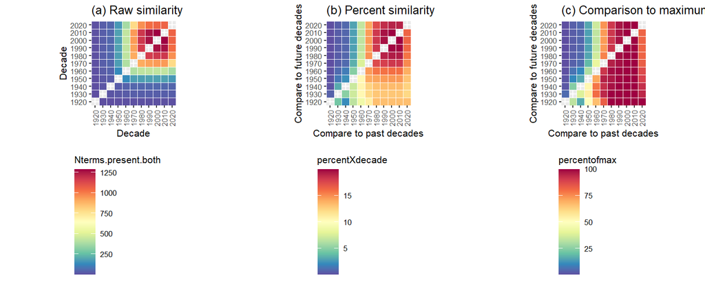

```r
#library(RColorBrewer)
#set color palette
  pal <- colorRampPalette(rev(brewer.pal(11, 'Spectral')), space='Lab')

  #Plot faceted heatmaps
    raw.coooc <- ggplot(data = decadeXdecade.melt.noNA, aes(x=Decade2.f, y=Decade1.f, fill=Nterms.present.both)) +
              geom_tile(colour="white",size=0.25) +
              #scale_x_continuous(breaks = scales::pretty_breaks(n = 10)) +
              labs(title = "(a) Raw similarity", x = "Decade", y = "Decade") +
              scale_fill_gradientn(colours = pal(100)) +
              scale_x_discrete(expand=c(0,0),
                   breaks=c("1920","1930","1940","1950","1960","1970","1980","1990","2000", "2010","2020"))+
              scale_y_discrete(expand=c(0,0),
                   breaks=c("1920","1930","1940","1950","1960","1970","1980","1990","2000", "2010","2020"))+
              coord_equal() +
              theme_grey(base_size=8) #set a base size for all fonts




 #Plot faceted heatmaps
    row.normed <- ggplot(data = decadeXdecade.melt.noNA.summ, aes(x=Decade2.f, y=Decade1.f, fill=percentXdecade)) +
              geom_tile(colour="white",size=0.25) +
              #scale_x_continuous(breaks = scales::pretty_breaks(n = 10)) +
              labs(title = "(b) Percent similarity", x = "Compare to past decades", y = "Compare to future decades") +
              scale_fill_gradientn(colours = pal(100)) +
              scale_x_discrete(expand=c(0,0),
                   breaks=c("1920","1930","1940","1950","1960","1970","1980","1990","2000", "2010","2020"))+
              scale_y_discrete(expand=c(0,0),
                   breaks=c("1920","1930","1940","1950","1960","1970","1980","1990","2000", "2010","2020"))+
              coord_equal() +
              theme_grey(base_size=8) #set a base size for all fonts


  #Plot faceted heatmaps
    percent.maxXdecade <- ggplot(data = decadeXdecade.melt.noNA.summ, aes(x=Decade2.f, y=Decade1.f, fill=percentofmax)) +
              geom_tile(colour="white",size=0.25) +
              #scale_x_continuous(breaks = scales::pretty_breaks(n = 10)) +
              labs(title = "(c) Comparison to maximum", x = "Compare to past decades", y = "Compare to future decades") +
              scale_fill_gradientn(colours = pal(100)) +
              scale_x_discrete(expand=c(0,0),
                   breaks=c("1920","1930","1940","1950","1960","1970","1980","1990","2000", "2010","2020"))+
              scale_y_discrete(expand=c(0,0),
                   breaks=c("1920","1930","1940","1950","1960","1970","1980","1990","2000", "2010","2020"))+
              coord_equal() +
              theme_grey(base_size=8) #set a base size for all fonts

    #library(ggpubr)  see: https://stackoverflow.com/questions/12041042/how-to-plot-just-the-legends-in-ggplot2
legend.a <- ggpubr::get_legend(raw.coooc)
legend.b <- ggpubr::get_legend(row.normed)
legend.c <- ggpubr::get_legend(percent.maxXdecade)


gridExtra::grid.arrange(raw.coooc+ theme(legend.position = "none", axis.text.x = element_text(angle = 90, vjust=0.5)),
                        row.normed+ theme(legend.position = "none", axis.text.x = element_text(angle = 90, vjust=0.5)),
                        percent.maxXdecade+ theme(legend.position = "none", axis.text.x = element_text(angle = 90, vjust=0.5)),
                        #
                        ggpubr::as_ggplot(legend.a),
                        ggpubr::as_ggplot(legend.b),
                        ggpubr::as_ggplot(legend.c),
                        ncol = 3, nrow = 2)
```

```r
#save plot as pdf

# pdf("Fig2_decadeXdecade.term.similarity.pdf", width=8, height=5.25)
  # gridExtra::grid.arrange(raw.coooc+ theme(legend.position = "none", axis.text.x = element_text(angle = 90, vjust=0.5)),
  #                         row.normed+ theme(legend.position = "none", axis.text.x = element_text(angle = 90, vjust=0.5)),
  #                         percent.maxXdecade+ theme(legend.position = "none", axis.text.x = element_text(angle = 90, vjust=0.5)),
  #                         #
  #                         ggpubr::as_ggplot(legend.a),
  #                         ggpubr::as_ggplot(legend.b),
  #                         ggpubr::as_ggplot(legend.c),
  #                         ncol = 3, nrow = 2)
  # dev.off()
```

# 4 Find diversity of title term use by decade

```r
# count unique stemwords total
whole.history.unique.stemword.n <- length(unique(summ_terms.presXdecade$stemmed.term))

# for each decade, how many terms are present?
summ_terms.presXdecade.count <- summ_terms.presXdecade %>% group_by(decade) %>% summarize(n.stemwords=n(),
                                                                                          percent.words.usedXdecade=(n.stemwords/whole.history.unique.stemword.n)*100)


summ_terms.presXdecade.count$decade.factor <- as.factor(summ_terms.presXdecade.count$decade)
summ_terms.presXdecade$decade.factor <- as.factor(summ_terms.presXdecade$decade)

nrow(summ_terms.presXdecade)
```

```
## [1] 7763
```

```r
#how many unique terms are present in full dataset (based on the top N terms from each decade)
length(unique(summ_terms.presXdecade$stemmed.term))
```

```
## [1] 1295
```

```r
#how many decades are each term "present" in?
summ_terms.ndecades.term.present <- summ_terms.presXdecade %>%
                                              group_by(stemmed.term) %>%
                                              summarize(n.decades.present=n(),
                                                        first.decade=min(decade),
                                                        last.decade=max(decade),
                                                        n.decades.missing=(last.decade-first.decade)/10,
                                                        percent.decades.present=(n.decades.present/(n.decades.present+n.decades.missing))*100)

# average percent decades present since first appearance
mean(summ_terms.ndecades.term.present$percent.decades.present)
```

```
## [1] 53.96095
```

```r
max(summ_terms.ndecades.term.present$percent.decades.present)
```

```
## [1] 66.66667
```

```r
min(summ_terms.ndecades.term.present$percent.decades.present)
```

```
## [1] 36.36364
```

```r
#when do new terms appear?
summ_terms.noveltermsXdecade <- summ_terms.ndecades.term.present %>%
                                              group_by(first.decade) %>%
                                              summarize(n.new.terms=n())

# add 0 for 2020 if no novel terms present
d2020 <- c("2020", "0")

summ_terms.noveltermsXdecade <- rbind.data.frame(summ_terms.noveltermsXdecade, d2020)
str(summ_terms.noveltermsXdecade)
```

```
## tibble [11 x 2] (S3: tbl_df/tbl/data.frame)
##  $ first.decade: chr [1:11] "1920" "1930" "1940" "1950" ...
##  $ n.new.terms : chr [1:11] "6" "34" "43" "150" ...
```

```r
summ_terms.noveltermsXdecade$n.new.terms <- as.numeric(summ_terms.noveltermsXdecade$n.new.terms)

#when do terms disappear?
summ_terms.extincttermsXdecade <- summ_terms.ndecades.term.present %>%
                                              group_by(last.decade) %>%
                                              summarize(n.extinct.terms=n())

#once a term is in use, they rarely go "extinct" and that's only been happening recently
summ_terms.extincttermsXdecade
```

| last.decade | n.extinct.terms |
| --- | --- |
| 2000 | 1 |
| 2010 | 235 |
| 2020 | 1059 |

```r
#show all extinct terms
subset(summ_terms.ndecades.term.present, last.decade<2020)
```

| stemmed.term | n.decades.present | first.decade | last.decade | n.decades.missing | percent.decades.present |
| --- | --- | --- | --- | --- | --- |
| abus | 5 | 1970 | 2010 | 4 | 55.55556 |
| advanc | 4 | 1980 | 2010 | 3 | 57.14286 |
| aethiop | 6 | 1960 | 2010 | 5 | 54.54545 |
| aggreg | 5 | 1970 | 2010 | 4 | 55.55556 |
| allianc | 5 | 1970 | 2010 | 4 | 55.55556 |
| alpha | 4 | 1980 | 2010 | 3 | 57.14286 |
| alpin | 4 | 1980 | 2010 | 3 | 57.14286 |
| alpinus | 4 | 1980 | 2010 | 3 | 57.14286 |
| altruism | 5 | 1970 | 2010 | 4 | 55.55556 |
| annual | 7 | 1950 | 2010 | 6 | 53.84615 |

[output cut: 226 more lines]

```r
# merge n decades back to when term used
summ_byuse_wdecadepressumm <- merge(summ_terms.ndecades.term.present,
                                    subset(summ_terms.presXdecade, select=c(decade, stemmed.term, ntimes.termpresentXdec)),
                                    by="stemmed.term", all.y=TRUE)


# keep only terms used in many decades
commonXdecades <- subset(summ_byuse_wdecadepressumm, n.decades.present>=8)
length(unique(commonXdecades$stemmed.term))
```

```
## [1] 150
```

```r
# add number of times each team used total
documentsXdecade <- d.stem.countXdoc.usedterms %>% group_by(decade) %>% summarize(number.docsXdecade=length(unique(docID)))

# merge n docs by decade to the commonly used terms
commonXdecades.meta <- merge(commonXdecades, documentsXdecade, by="decade", all.x=TRUE)
commonXdecades.meta$normalized.useXdecade <- (commonXdecades.meta$ntimes.termpresentXdec / commonXdecades.meta$number.docsXdecade)*100
#commonXdecades.meta$log.normalized.useXdecade <- log10(commonXdecades.meta$normalized.useXdecade)

commonXdecades.meta.cast <- reshape2::dcast(commonXdecades.meta, stemmed.term~decade, value.var="normalized.useXdecade")

commonXdecades.decadeXterm.cast <- reshape2::dcast(commonXdecades.meta, stemmed.term~decade, value.var="ntimes.termpresentXdec")

#diversity in stemword use X decade
library(vegan)
#diversity(data[-1], index="shannon")

#decades by terms matrix format
commonXdecades.decadeXterm.cast.mx <- matrix.please(commonXdecades.decadeXterm.cast)
commonXdecades.decadeXterm.cast.mx[is.na(commonXdecades.decadeXterm.cast.mx)] <- 0 # d[is.na(d)] <- 0
term.diversityXdecade <- diversity(t(commonXdecades.decadeXterm.cast.mx), index = "shannon") #default is shannon
str(term.diversityXdecade)
```

```
##  Named num [1:11] 1.61 3.1 3.5 4.29 4.26 ...
##  - attr(*, "names")= chr [1:11] "1920" "1930" "1940" "1950" ...
```

```r
term.diversityXdecade <- as.data.frame(term.diversityXdecade)
term.diversityXdecade$decade <- row.names(term.diversityXdecade)
```

# 5 plot diversity of stemword use by decade

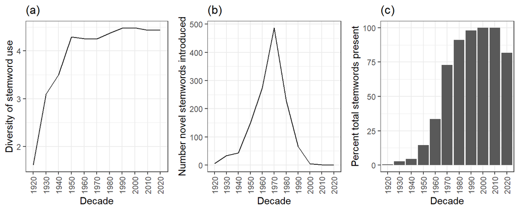

```r
#diversity
plot.diversity <- ggplot(term.diversityXdecade, aes(x=decade, y=term.diversityXdecade, group=1)) +
  geom_line() +
  labs(x="Decade", y="Diversity of stemword use", title="(a)") +
  #scale_y_continuous(labels = scales::comma) +
  #ylim(0,max(term.diversityXdecade$term.diversityXdecade)) +
  theme_bw() +
  theme(axis.text.x = element_text(angle = 90, vjust=0.5))

#novel words
novelty <- ggplot(summ_terms.noveltermsXdecade, aes(x=first.decade, y=n.new.terms, group=1)) +
  geom_line() +
  labs(x="Decade", y="Number novel stemwords introduced", title="(b)") +
  #scale_y_continuous(labels = scales::comma) +
  #ylim(0,max(term.diversityXdecade$term.diversityXdecade)) +
  theme_bw() +
  theme(axis.text.x = element_text(angle = 90, vjust=0.5))

#extinction
extinction <- ggplot(summ_terms.extincttermsXdecade, aes(x=last.decade, y=n.extinct.terms, group=1)) +
  geom_line() +
  labs(x="Decade", y="Number novel stemwords introduced", title="(b)") +
  #scale_y_continuous(labels = scales::comma) +
  #ylim(0,max(term.diversityXdecade$term.diversityXdecade)) +
  theme_bw() +
  theme(axis.text.x = element_text(angle = 90, vjust=0.5))

#percent words in whole corpus used in each decade
percent.use <- ggplot(summ_terms.presXdecade.count, aes(x=decade.factor, y=percent.words.usedXdecade)) +
  geom_bar(stat="identity") +
  labs(x="Decade", y="Percent total stemwords present", title="(c)") +
  #scale_y_continuous(labels = scales::comma) +
  #ylim(0,max(term.diversityXdecade$term.diversityXdecade)) +
  theme_bw() +
  theme(axis.text.x = element_text(angle = 90, vjust=0.5)) #+
  #xlim(1915,2025)


#print plot
grid.arrange(plot.diversity, novelty, percent.use, ncol = 3, nrow = 1)
```

```r
#save plot as pdf
  # pdf("FigTKTK_stemworddiversitynovelty.pdf", width=8, height=3.25)
  # grid.arrange(plot.diversity, novelty, percent.use, ncol = 3, nrow = 1)
  # dev.off()
```